# PA1_template

liyangfan

2019/7/24

## week2 project1

### Loading and preprocessing the data

Read in the csv file “activity” and exclude the missing values in order to handle the file better in the future.

```r
data <- read.csv("activity.csv")
data <- data[complete.cases(data),]
```

### What is mean total number of steps taken per day?

Import the dplyr package and make a dataframe “daycount” showing the total number of step taken for every seperate day. Then, plot a histogram according to the table.

```r
library(dplyr)
```

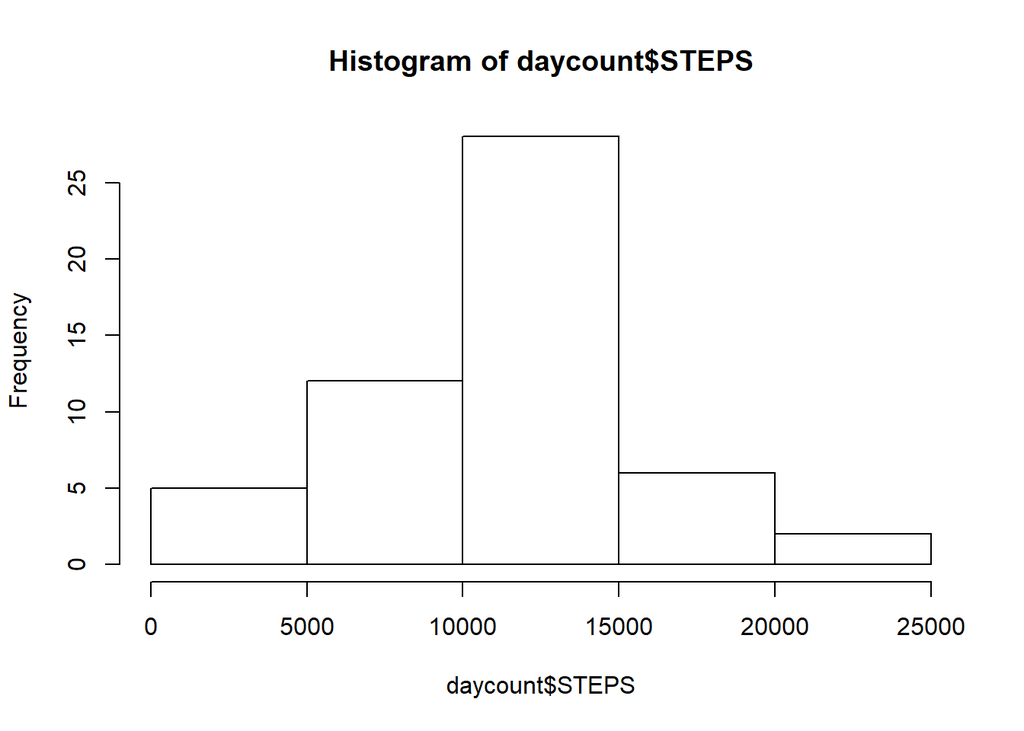

```r
daycount <- data %>% group_by(date) %>% summarize(STEPS = sum(steps))
hist(daycount$STEPS)
```

Calculate the mean and median of the total steps per day

```r
mean(daycount$STEPS)
```

```
## [1] 10766.19
```

```r
median(daycount$STEPS)
```

```
## [1] 10765
```

###What is the average daily activity pattern?

Construct a datafram “intervalcount” showing the average steps taken through all days per interval Then plot the time series required

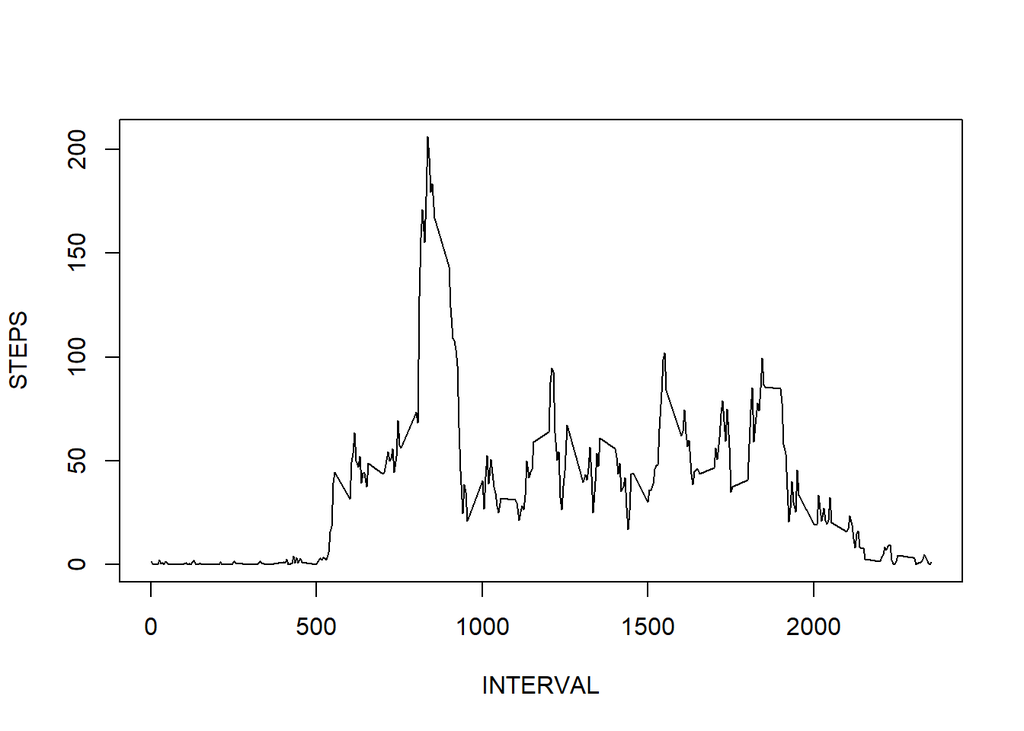

```r
intervalcount <- data %>% group_by(interval)%>% summarize(STEPS = mean(steps))
plot(intervalcount$interval,intervalcount$STEPS,xlab = "INTERVAL", ylab = "STEPS",type = "l")
```

Get the the interval which corresponding to the maximum number of steps per interval

```r
intervalcount[order(intervalcount$STEPS,decreasing = TRUE),][1,]
```

```
## # A tibble: 1 x 2
##   interval STEPS
##      <int> <dbl>
## 1      835  206.
```

###Imputing missing values

Import the activity.csv again and at this time keep the NA values subset the rows with NA values “nadata” and count the row numbers. In this case, get the totoal number of NA values in the file.

```r
originaldata <- read.csv("activity.csv")
nadata <- originaldata[is.na(originaldata$steps),]
nrow(nadata)
```

```
## [1] 2304
```

My strategy here is using the average steps taken per interval to fill the NA values. At first , construct a function to complete the substitution and use the mapply function to act as a loop in order to fill all the NA values through out the whole “originaldata” dataframe. Thus we get a new “originaldata” with no NA values

```r
input <- function(thestep,theinterval){
  if(is.na(thestep)){
    value <- intervalcount$STEPS[which(intervalcount$interval==theinterval)]
  }
  else{
    value <- thestep
  }
  return(value)
}
originaldata$steps <- mapply(input,originaldata$steps,originaldata$interval)
```

Secondly, calculate the total number of steps taken per day using this new data frame and get a new table “withnadaycount” and plot the corresponding histogram using this table.

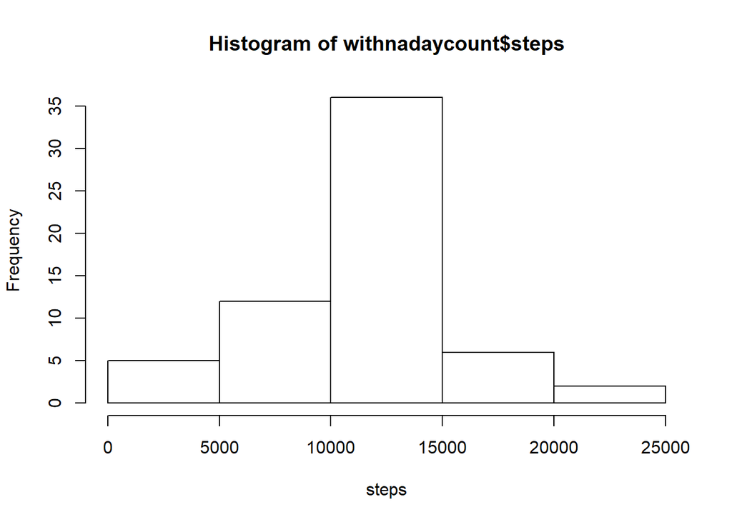

```r
withnadaycount <- originaldata %>% group_by(date)%>% summarize(steps = sum(steps))
hist(withnadaycount$steps,xlab = "steps")
```

At last calculate the new mean and median

```r
mean(withnadaycount$steps)
```

```
## [1] 10766.19
```

```r
median(withnadaycount$steps)
```

```
## [1] 10766.19
```

###Are there differences in activity patterns between weekdays and weekends?

Construct a function which can transform the specific name of the weekdays into either“weekday”,or “weekend”. Then construct a new column for the original data called“daynote” showing whether this day is a weekday of weekend.

```r
originaldata$date <- as.Date(originaldata$date)
isweekday<-function(idate){
   if (weekdays(idate) %in% c("星期日", "星期六"))
       return("weekend")
   else
       return("weekday")
}
originaldata$daynote<- mapply(isweekday,originaldata$date)
```

plot the time series for the weekday and weekend respectively.

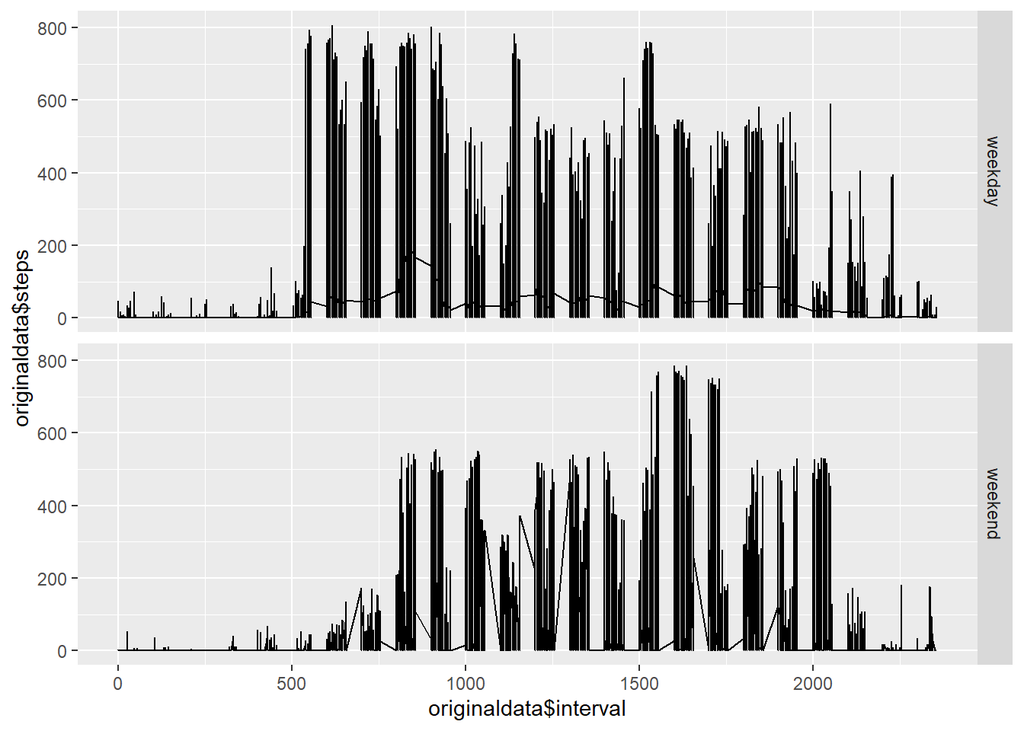

```r
library(ggplot2)
ggplot(originaldata,aes(originaldata$interval,originaldata$steps))+geom_line()+facet_grid(originaldata$daynote~.)
```